# Kasai Province (DRC)

Institutional Module

The Community Trust Index assesses the level of trust in the Red Cross response during the 16th Ebola outbreak in Kasai province, focusing on perceptions of its actions, competencies, and the role of volunteers and staff. The analysis covers the outbreak period from the first recorded case on 20 August 2025 to the last reported case on 19 October 2025, during which 53 confirmed cases, 11 suspected cases, and 45 deaths were reported.

**Summary**

- **Strong overall performance**, slight values gap: Competencies (9.27) are slightly higher than values (9.08), suggesting solid delivery but room to strengthen trust and perception.
- **Transparency** is the main weakness: At 7.7, it is the lowest score by far, indicating a need for clearer communication and more visible decision-making.
- **Engagement** drives higher scores: People who interact more (feedback, support requests, volunteering) consistently rate services higher, showing engagement is a key perception driver.
- Lower scores linked to **low engagement and vulnerability**: Less engaged groups (no feedback, inactive, some locations like Mweka 1) report lower scores, highlighting the need for targeted outreach.

# Sampling

A stratified random sampling approach was used to ensure representation across key population groups, including differences in age, gender, education level, and geographic location. Data collection was carried out by Red Cross volunteers as part of efforts to assess community trust during the Ebola response.

*See metrics: Metrics*

## Geographic

The survey sample closely reflects the population distribution across Bulape and Mweka, indicating that the sampling is broadly representative of the target population. Mweka accounts for 58.2% of survey respondents compared with 54.1% of the population, making it slightly overrepresented in the sample. Conversely, Bulape represents 41.8% of respondents versus 45.9% of the population, indicating slight underrepresentation.

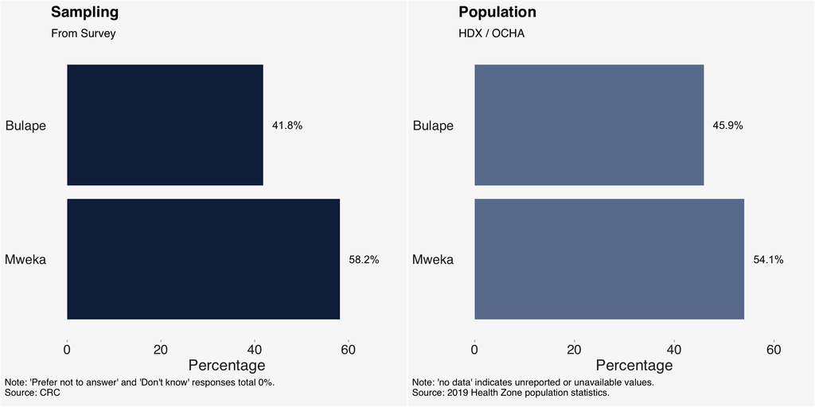

## Coverage

[interactive chart not shown]

## Gender and Age

The age and sex distribution of the survey sample broadly aligns with the population profile, suggesting that the sample is generally representative across demographic groups. Some differences are evident, with younger adults aged 20–29 slightly underrepresented in both females and males, while males aged 30–49 and 50–59 are somewhat overrepresented in the survey compared to the population. Overall, however, the variations between the sample and population remain relatively small. These small imbalances may require post-stratification adjustment.

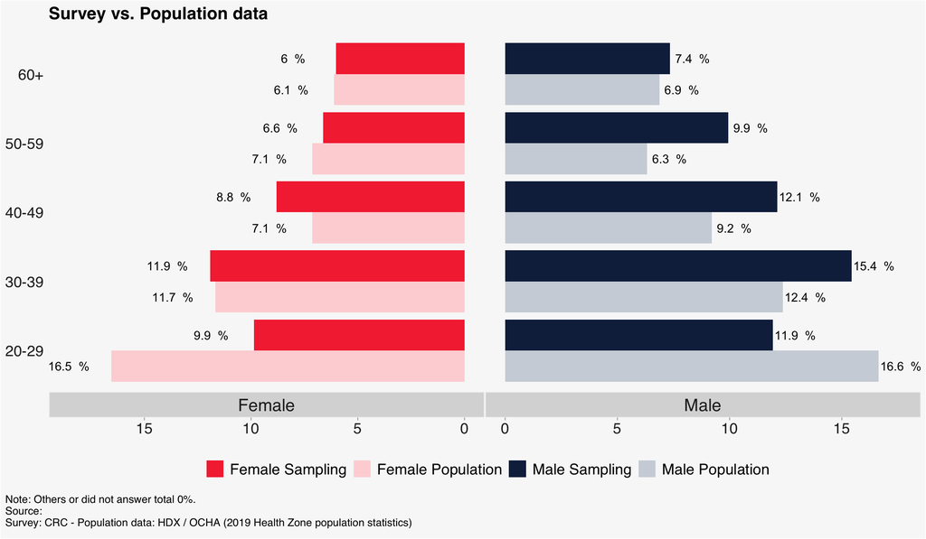

## Education

Education data is available only for the survey sample, with no comparable population data for validation. Among respondents, the largest proportion reported having completed secondary school (45.7%), followed by university education (21.2%) and primary school education (20.1%). Smaller shares reported no formal education (10.7%) or advanced university-level education (2.2%).

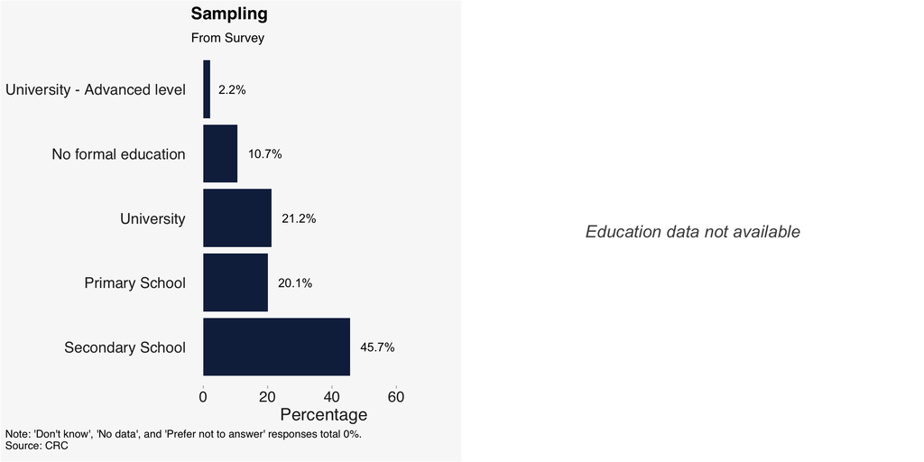

## Employment

Employment data is available only for the survey sample, with no corresponding population data available for comparison. Among respondents, unemployment is the most commonly reported status (32.0%), followed by irregular/informal employment (26.5%) and regular/partial employment (19.1%). Smaller proportions reported being not active (17.0%) or students (5.3%). As no comparable population breakdown is available, these results should be interpreted with caution.

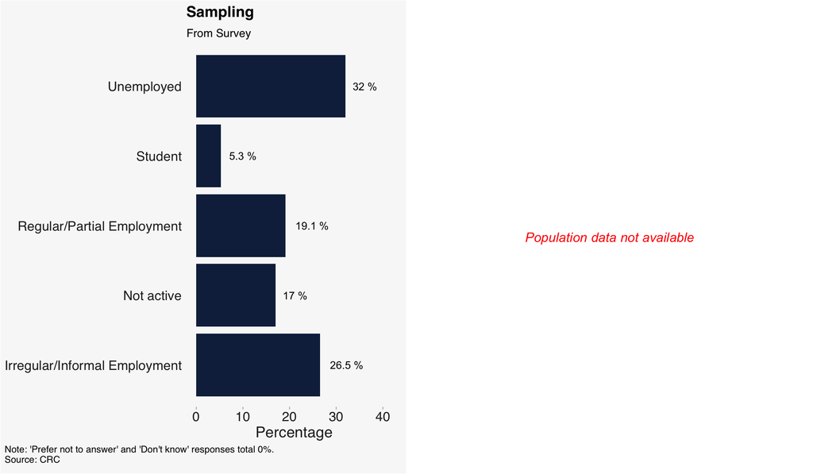

## Limitations

The data presented in this study should be interpreted with caution due to methodological limitations related to sampling and representativeness.

- While the survey broadly reflects the population distribution across Bulape and Mweka, slight imbalances remain:
  - Mweka is somewhat over-represented in the sample;
  - Bulape is slightly under-represented.
- Minor differences are also observed in the age and sex distribution, including:
  - Younger adults being slightly under-represented;
  - Some older male age groups being over-represented compared with population estimates.
- No comparable population benchmark data were available for education and employment characteristics, limiting the ability to assess representativeness across these variables.
- Although post-stratification adjustments were applied using available demographic variables to improve comparability, these corrections cannot fully eliminate bias introduced by the sampling approach and data limitations.
- As a result, the findings should be interpreted as broadly indicative rather than fully representative of the wider population, and caution is advised when generalizing beyond the surveyed sample.

# Survey Results

The charts below present the survey answers as percentages, offering visualization of the Community Trust levels by subdimensions. They illustrate the distribution of community’s perceptions of the competencies and values.

## Perception of trust

### Competencies

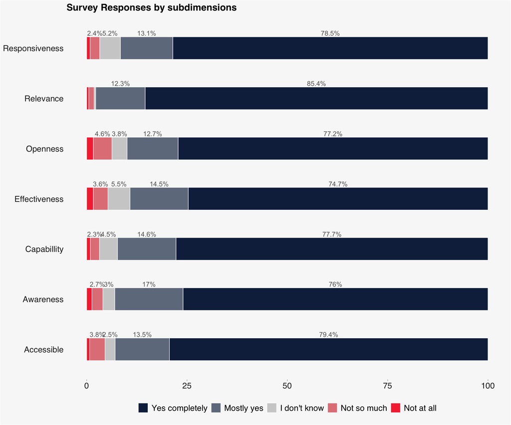

### Values

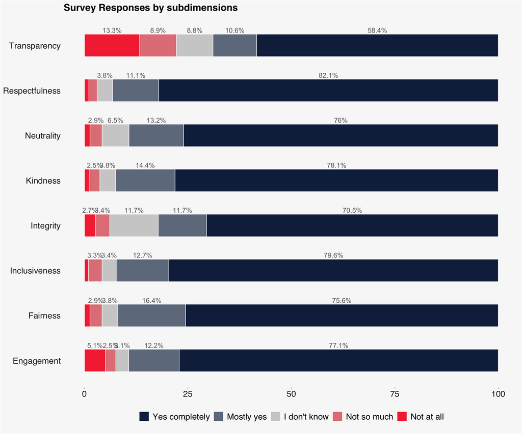

## Contextual questions

This section presents findings on community members’ experiences with and behaviors toward the Red Cross. These questions explore interactions, perceptions, and engagement patterns, offering insights into how the Red Cross is viewed and utilized within the community.

### Experiences

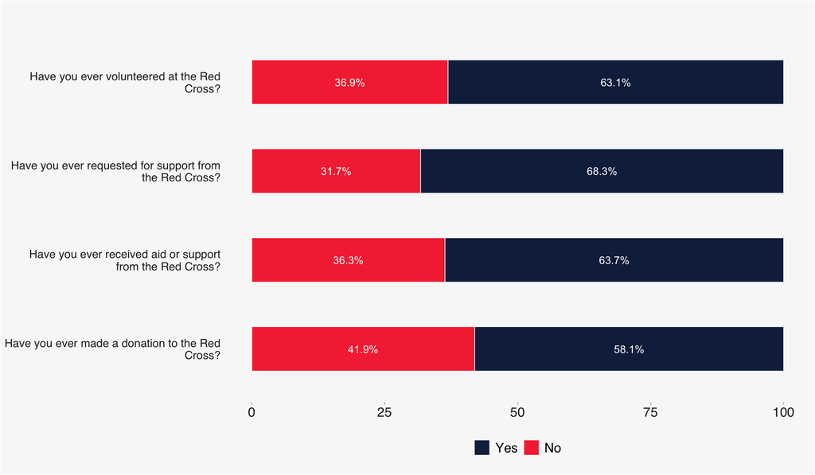

### Behaviours

Respondents reported very high levels of positive engagement with Red Cross information and services, with most having followed Red Cross advice in a crisis (97.2%), shared information received with others (94.3%), provided feedback (86.5%), and recommended the organization to people needing support (75.4%).

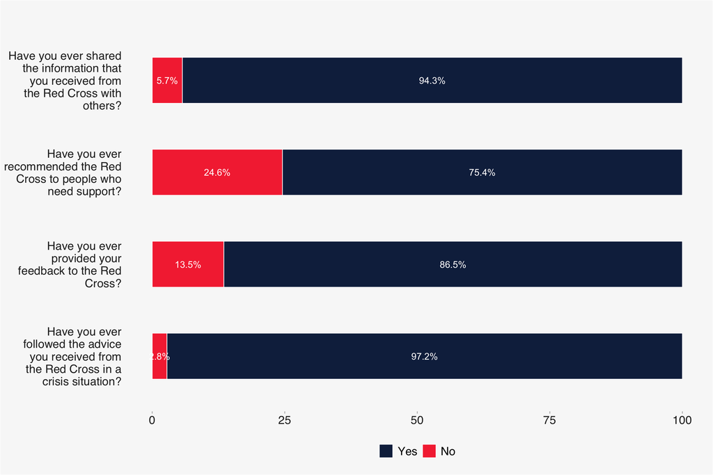

### Intention

Respondents expressed very strong willingness to engage with the Red Cross in the future, with the majority reporting they are very likely to volunteer, recommend services, provide feedback, donate, follow Red Cross advice, share information, and request support, generally ranging between 67% and 80% across all actions.

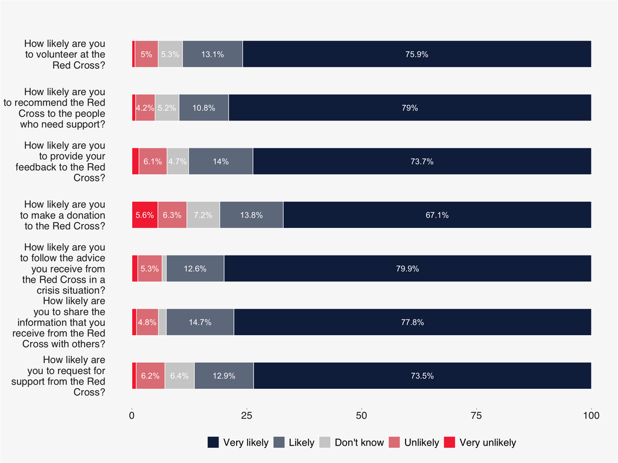

# Score

This score is derived from responses to questions that assess perceptions of competencies and values, providing a comprehensive measure of trust. A higher score indicates stronger trust, suggesting that community members believe their needs are being addressed and their values are respected. *Learn more about scoring method: Methods*

## Overall Score

Overall, the findings suggest that respondents hold highly favorable perceptions of the organization’s competencies and values, with all dimensions scoring above average. However, transparency stands out as the comparatively weakest dimension and may represent a priority area for further improvement.

*Learn more about weighting process: Weighting*

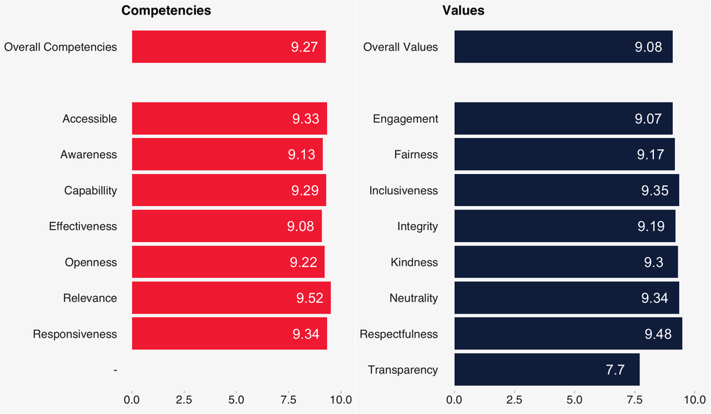

## Score by factors

Perceptions of Red Cross competencies and values are consistently high across all respondent groups, with most scores ranging between 8 and 10 out of 10, indicating broadly positive perceptions overall.

- Competency scores are generally slightly higher than value scores across most demographic and geographic categories.
- The highest ratings are observed among respondents in Bulape, students, and those with higher education levels, suggesting particularly strong perceptions among these groups.
- Comparatively lower scores are reported in certain health areas such as Mweka 1, among respondents not born in DRC, and among individuals with no prior engagement with the Red Cross.

Despite some variation across groups, all scores remain strongly positive, indicating consistently favorable perceptions of the Red Cross across the surveyed population.

*Distribution of mean scores for values and competencies per demographic questions*

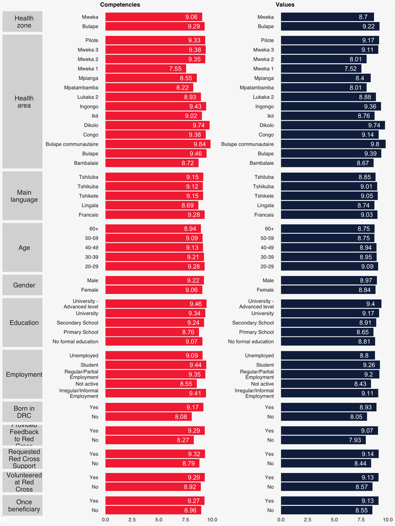

## Score by respondent profile

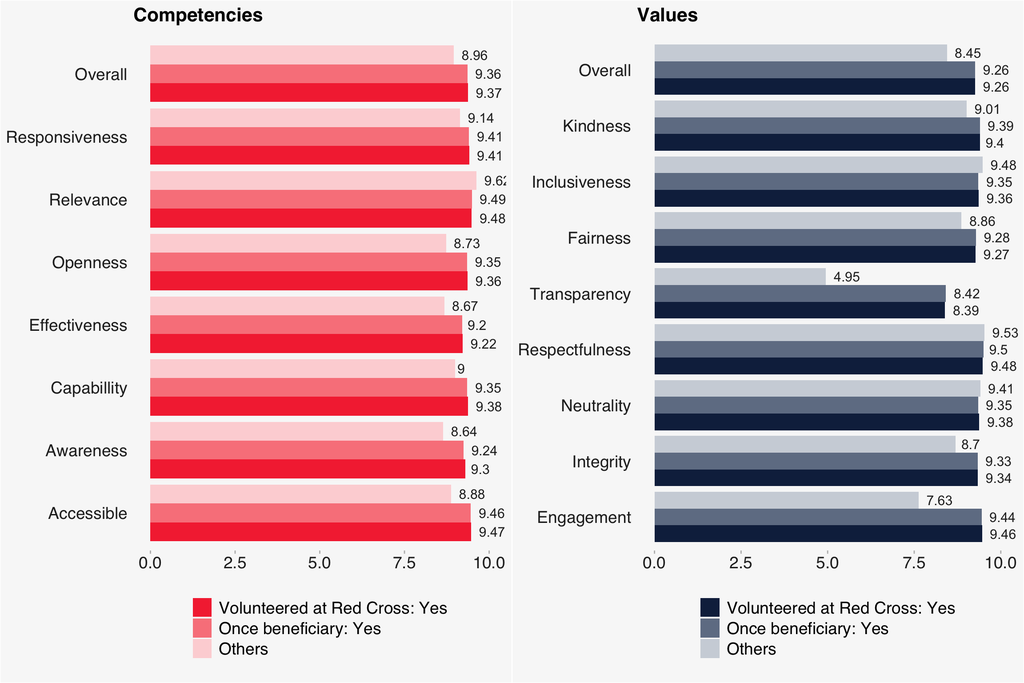

# Methods and Metrics

## Metrics

### Gender

Respondents by Gender

| Gender | Total Respondents | Percentage (%) |
| --- | --- | --- |
| Female | 653 | 43.2 |
| Male | 857 | 56.7 |
| Other or did not answer | 1 | 0.1 |
| Total | 1511 | 100.0 |

### Age

Respondents by Age Group

| Age Group | Total Respondents | Percentage (%) |
| --- | --- | --- |
| 20-29 | 329 | 21.8 |
| 30-39 | 414 | 27.4 |
| 40-49 | 316 | 20.9 |
| 50-59 | 250 | 16.5 |
| 60+ | 202 | 13.4 |

### Geographic

Respondents by Admin2 and Admin1

| Admin1 | Admin2 | Total Respondents | Percentage (%) |
| --- | --- | --- | --- |
| Bulape | Bulape | 172 | 27.2 |
| Bulape | Bambalaie | 99 | 15.7 |
| Bulape | Bulape communautaire | 94 | 14.9 |
| Bulape | Ingongo | 91 | 14.4 |
| Bulape | Dikolo | 83 | 13.1 |
| Bulape | Mpianga | 64 | 10.1 |
| Bulape | Mpatambamba | 28 | 4.4 |
| Bulape | Bupole | 1 | 0.2 |
| Bulape | TOTAL | 632 | 100.0 |
| Mweka | Pilote | 138 | 15.7 |
| Mweka | Mweka 2 | 135 | 15.4 |
| Mweka | Mweka 3 | 133 | 15.1 |
| Mweka | Congo | 130 | 14.8 |
| Mweka | Ikit | 125 | 14.2 |
| Mweka | Lukaka 2 | 120 | 13.7 |
| Mweka | Mweka 1 | 96 | 10.9 |
| Mweka | 0 | 1 | 0.1 |
| Mweka | Tshikuluka | 1 | 0.1 |
| Mweka | TOTAL | 879 | 100.0 |

### Relationship with RC

Respondents by relationship with RC

| Profile | Total Respondents |
| --- | --- |
| Volunteered at Red Cross: Yes | 951 |
| Once beneficiary: Yes | 961 |

## Methods

**Scoring methodology**

To determine the score, we employ the following method:

1. Survey Structure The CTI survey includes multiple questions grouped under sub-dimensions of two main categories:
   - Competencies (e.g., reliability, effectiveness, technical proficiency)
   - Values (e.g., ethics, integrity, fairness, transparency)
2. Sub-Dimension Scoring

   Each sub-dimension comprises several survey items (questions).Respondents answer on a Likert-type scale (1 to 4 - Don’t not is excluded). For each sub-dimension:

   *Sub-dimension Score = ∑ (Weighted Response Scores) / Number of Items*

If weights are not empirically derived, equal weighting is typically applied to each item.

3. Dimension Scoring

Once all sub-dimension scores are calculated, the Competency Score and Values Score are each derived as the arithmetic mean of their respective sub-dimension scores:

- *Competency Score = ∑(Sub-dimension Scores for Competency) /𝑛*
- *Values Score = ∑(Sub-dimension Scores for Values)/𝑚*

where 𝑛 and 𝑚 are the number of sub-dimensions in each category.

4. Overall Scoring

   The final Community Trust Index score is the arithmetic mean of the Competency and Values scores:
- *CTI Score = (Competency Score + Values Score)/2*

## Weighting

**Weighting vs. unweighting**

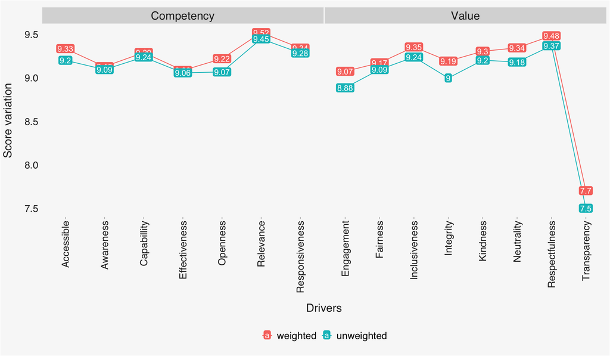

## Drivers Correlation

**Correlation matrix**

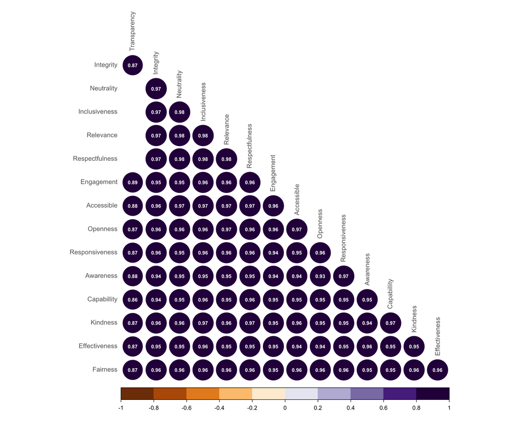

## Significance testing

**Significance testing**

| Pillar | Drivers | Volunteered at Red Cross: Yes-Once beneficiary: Yes | Volunteered at Red Cross: Yes-Others | Once beneficiary: Yes-Others |
| --- | --- | --- | --- | --- |
| Competency | Capabillity | No | Yes | Yes |
| Competency | Responsiveness | No | No | No |
| Competency | Awareness | No | Yes | Yes |
| Competency | Accessible | No | Yes | Yes |
| Competency | Openness | No | Yes | Yes |
| Competency | Relevance | No | Yes | Yes |
| Competency | Effectiveness | No | Yes | Yes |
| Value | Kindness | No | No | No |
| Value | Fairness | No | Yes | Yes |
| Value | Inclusiveness | No | Yes | Yes |
| Value | Respectfulness | No | Yes | Yes |
| Value | Engagement | No | Yes | Yes |
| Value | Integrity | No | Yes | Yes |
| Value | Transparency | No | Yes | Yes |
| Value | Neutrality | No | Yes | Yes |

# Download

Download Summary Excel File